# R Notebook

```r
library(tidyverse)
library(brms)
library(lme4)
library(lmerTest)
library(plotrix)
library(stringr)
library(readxl)
library(rpart)
library(Hmisc)
library(Metrics)
library(RColorBrewer)
library(scales)
```

# Priors

Read in the prior gathering experimental data and plot the priors for the chair and the footstool

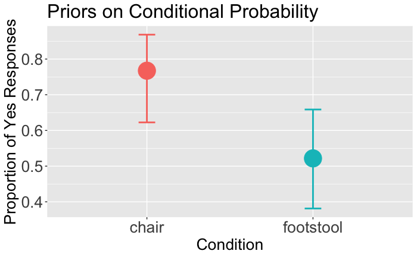

```r
d = read.csv("./data/priors_nonmodal.csv", comment = "#", header=F, col.names =
                      c("time", "participant", "controller", "item", "element", "type", "group", "field_name", "field_value"))
d = d %>%
  select(-controller, -item, -element, -group) %>%
  filter(field_name != "_REACTION_TIME_") %>%
  group_by(time, participant) %>%
    mutate(condition = type[type=="chair" | type=="footstool"]) %>%
  ungroup() %>%
  select(-type) %>%
  spread(field_name, field_value) %>%
  filter(q1 == "Sam" & q2 == "green" & nativeq == "yes") %>%
  select(-q1, -q2, -nativeq) %>%
  mutate(input = if_else(input == "yes", 1, 0)) %>%
  distinct(participant, .keep_all = T)
d %>%
  group_by(condition) %>%
    summarise(m = mean(input),
              upper = binconf(sum(input), n())[2],
              lower = binconf(sum(input), n())[3],
              n=n()) %>%
  ungroup() %>%
  ggplot(aes(x=condition, y=m, ymax=upper, ymin=lower, color=condition)) +
    geom_point(stat="identity", position="dodge", size=10) +
    geom_errorbar(width=.1, alpha=1, size=1) +
    ylab("Proportion of Yes Responses") +
    xlab("Condition") +
    ggtitle("Priors on Conditional Probability") +
    theme(legend.position = 'none',
          axis.text=element_text(size=20),
          title=element_text(size=20),
          legend.text=element_text(size=20),
          axis.title=element_text(size=20),
          strip.text.x = element_text(size = 20))
```

```r
#ggsave("./images/priors.png", width = 4, height = 7)
```

## Statistics

Statistical test: are the priors different in the two conditions?

```r
d_stat = d %>%
  group_by(condition) %>%
    summarise(success = sum(input),
              n = n())%>%
  ungroup()
a_success = as.numeric(d_stat[1,"success"])
a_n = as.numeric(d_stat[1,"n"])
a_fail = a_n - a_success
b_success = as.numeric(d_stat[2,"success"])
b_n = as.numeric(d_stat[2,"n"])
b_fail = b_n - b_success
fisher.test(matrix(c(a_success, b_success, a_fail, b_fail), nrow = 2))
```

```
    Fisher's Exact Test for Count Data

data:  matrix(c(a_success, b_success, a_fail, b_fail), nrow = 2)
p-value = 0.02636
alternative hypothesis: true odds ratio is not equal to 1
95 percent confidence interval:
 1.114279 8.469131
sample estimates:
odds ratio
  2.986506
```

# Elicitation Experiment

Read in the elicitation data and plot the results

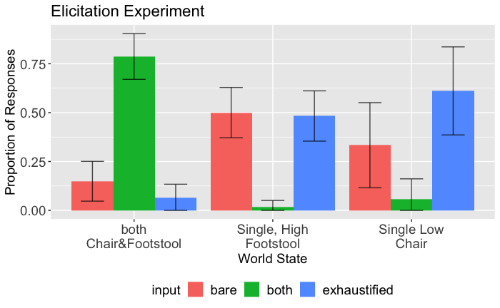

```r
d = read.csv("./data/elicitation.csv", comment = "#", header=F, col.names =
                      c("time", "participant", "controller", "item", "element", "type", "group", "field_name", "field_value"))
d_elicit = d %>%
  select(-controller, -item, -element, -group) %>%
  filter(field_name != "_REACTION_TIME_") %>%
  group_by(time, participant) %>%
    mutate(condition = type[1]) %>%
  ungroup() %>%
  select(-type) %>%
  spread(field_name, field_value) %>%
  #filter(q1 == "Alex" & q2 == "green" & nativeq == "yes") %>%
  select(-q1, -q2, -nativeq) %>%
  drop_na() %>%
  mutate(input = as.character(input)) %>%
  mutate(input = if_else((input == "onlyfootstool" | input == "onlychair"), "exhaustified", input)) %>%
  mutate(input = if_else((input == "footstool" | input == "chair"), "bare", input)) %>%
  separate(condition, sep="-", into=c("world_state", "conditional_prob")) %>%
  mutate(input = as.factor(input)) %>%
  distinct(participant, .keep_all = T) %>%
  mutate(condition = paste(world_state, conditional_prob, sep = "_")) %>%
  mutate(condition = if_else(startsWith(condition, "both"), "both", condition)) %>%
  select(-world_state, -conditional_prob)
d_elicit %>%
  group_by(condition) %>%
    mutate(n_in_cond = n()) %>%
  ungroup() %>%
  group_by(condition, input) %>%
    summarise(m = n()/n_in_cond[1],
              se = sqrt(((n()/n_in_cond[1]) * (1-(n()/n_in_cond[1])))/n_in_cond[1]),
              upper = m+1.96*se,
              lower = m-1.96*se,
              n=n()) %>%
  ungroup() %>%
  ggplot(aes(x=condition, y=m, ymax=upper, ymin=pmax(lower, 0), fill=input)) +
    geom_bar(stat="identity", position="dodge") +
    geom_errorbar(color="black", width=.5, position=position_dodge(width=.9), alpha=0.7) +
    ylab("Proportion of Responses") +
    xlab("World State") +
    ggtitle("Elicitation Experiment") +
    scale_x_discrete(labels= c("both\nChair&Footstool", "Single, High\nFootstool", "Single Low\nChair")) +
    theme(legend.position = 'bottom',
          axis.text=element_text(size=14),
          title=element_text(size=14),
          legend.text=element_text(size=14),
          axis.title=element_text(size=14),
          strip.text.x = element_text(size = 14))
ggsave("elicitation-final.png", width = 7, height = 7)
```

# Interpretation Experiment

Read in the interpretation data and plot the results

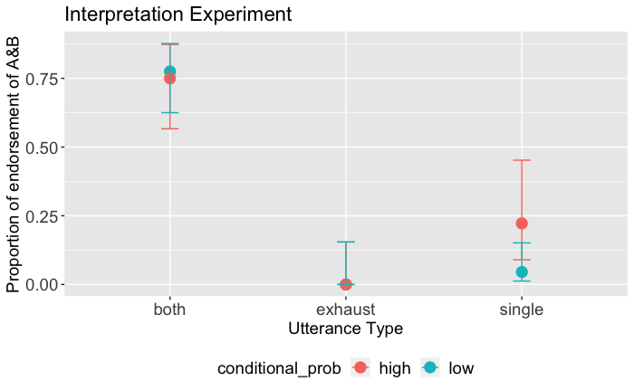

```r
d = read.csv("./data/interpretation.csv", comment = "#", header=F, col.names =
                      c("time", "participant", "controller", "item", "element", "type", "group", "field_name", "field_value"))
d_interpret = d %>%
  select(-controller, -item, -element, -group) %>%
  filter(field_name != "_REACTION_TIME_") %>%
  filter(field_name != "input") %>% #Due to dummy data that I had previously populated the database with. Just filter this out.
  group_by(time, participant) %>%
    mutate(condition = type[1]) %>%
  ungroup() %>%
  select(-type) %>%
  spread(field_name, field_value) %>%
  #filter(q1 == "Alex" & q2 == "green" & nativeq == "yes") %>%
  select(-q1, -q2, -nativeq) %>%
  drop_na() %>%
  mutate(input = if_else(input1=="yes" & input2=="yes", 1, 0)) %>%
  mutate(chair = if_else(input1=="yes" & input2=="no", 1, 0)) %>%
  mutate(footstool = if_else(input1=="no" & input2=="yes", 1, 0)) %>%
  mutate(none = if_else(input1=="no" & input2=="no", 1, 0)) %>%
  separate(condition, sep="_", into=c("utterance", "conditional_prob", "modal")) %>%
  select(-input1, -input2) %>%
  distinct(participant, .keep_all = T)
d_interpret %>%
  filter(modal=="nomodal") %>%
  group_by(utterance, conditional_prob, modal) %>%
    summarise(m = mean(input),
              upper = binconf(sum(input), n())[2],
              lower = binconf(sum(input), n())[3],
              n=n()) %>%
  ungroup() %>%
  ggplot(aes(x=utterance, y=m, ymax=upper, ymin=lower, color=conditional_prob)) +
    geom_point(stat="identity", position="dodge", size=4) +
    geom_errorbar(width=.1, alpha=1) +
    ylab("Proportion of endorsement of A&B") +
    xlab("Utterance Type") +
    ggtitle("Interpretation Experiment") +
    #facet_wrap(~modal) +
    theme(legend.position = 'bottom',
          axis.text=element_text(size=14),
          title=element_text(size=14),
          legend.text=element_text(size=14),
          axis.title=element_text(size=14),
          strip.text.x = element_text(size = 14))
```

```r
#ggsave("interpretation.png", width= 3, height = 5 )
```

# RSA Model

‘fit_results_nonmodal.csv’ – each row is a model run. The alpha, difference between cost 1 and cost 2 (“diff”), and the fit to the human data are recorded. This plot shows the goodness of fit as a funciton of alpha and diff, for the listener.

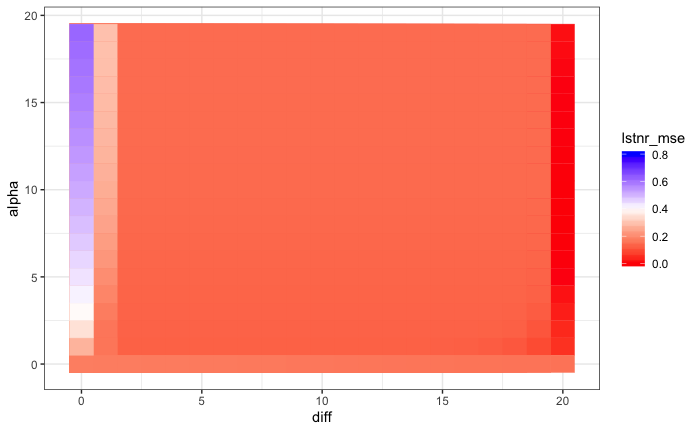

```r
d = read.csv("./modeling/fit_results_nonmodal.csv")
d = d %>%
  mutate(diff = c2-c1) %>%
  filter(diff >= 0)
d %>%
  ggplot(aes(x=diff, y=alpha, fill=lstnr_mse, color=lstnr_mse)) +
    geom_tile(width=1, height=1) +
    scale_fill_gradient2(low = "red", mid = "white", high = "blue", midpoint = 0.4, limit = c(0,0.8)) +
    scale_color_gradient2(low = "red", mid = "white", high = "blue", midpoint = 0.4, limit = c(0,0.8)) +
    theme_bw()
```

This plot shows the goodness of fit as a funciton of alpha and diff, for the speaker.

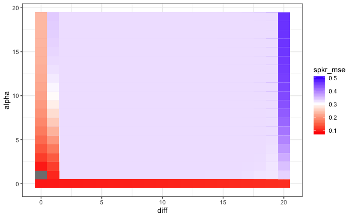

```r
d %>%
  ggplot(aes(x=diff, y=alpha, fill=spkr_mse)) +
    geom_tile(width=1, height=1) +
    scale_fill_gradient2(low = "red", mid = "white", high = "blue", midpoint = 0.3, limit = c(0.08,0.5)) +
    theme_bw()
```

This plot shows the goodness of fit as a funciton of alpha and diff, for both the listener and the speaker.

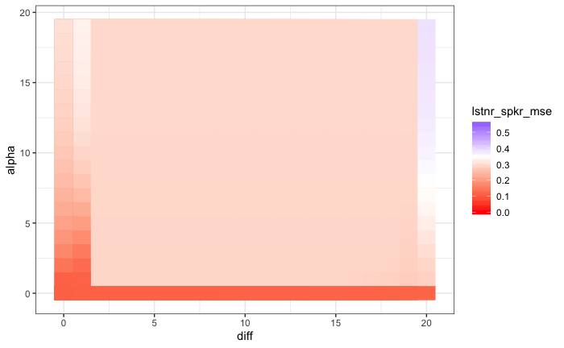

```r
d %>%
  ggplot(aes(x=diff, y=alpha, fill=lstnr_spkr_mse, colour=lstnr_spkr_mse)) +
    geom_tile(width=1, height=1) +
    scale_color_gradient2(low = "red", mid = "white", high = "blue", midpoint = 0.35, limit = c(0,0.55)) +
    scale_fill_gradient2(low = "red", mid = "white", high = "blue", midpoint = 0.35, limit = c(0,0.55)) +
    theme_bw()
```

# Plot model results + human results

## Interpretation Experiment

Plot the best fits for the “Free” and “Fixed” fit models, as well as the human data. This graph is for the interpretation experiment.

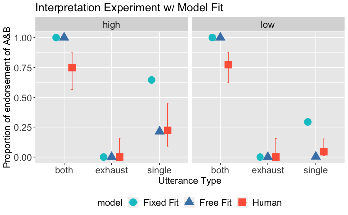

```r
d_rank = d %>%
  arrange(lstnr_mse)
free_fit = d_rank[1,4:5]
free_fit$model = "Free Fit"
free_fit$exhaust.low = 0
free_fit$exhaust.high = 0
free_fit$both.low = 1
free_fit$both.high = 1
d_rank = d %>%
  filter(c2 <= 2 * c1) %>%
  arrange(lstnr_mse)
fixed_fit = d_rank[1,4:5]
fixed_fit$model = "Fixed Fit"
fixed_fit$both.low = 1
fixed_fit$both.high = 1
fixed_fit$exhaust.low = 0
fixed_fit$exhaust.high = 0
model_res = rbind(fixed_fit, free_fit) %>%
  gather(utterance,m,c(lstnr.low,lstnr.high, both.low, both.high, exhaust.low, exhaust.high)) %>%
  separate(utterance, c("utterance","conditional_prob"), sep="\\.") %>%
  mutate(utterance=if_else(utterance=="lstnr", "single", utterance)) %>%
  mutate(upper = m,
         lower = m,
         n=m)

d_interpret_model = d_interpret %>%
  filter(modal=="nomodal") %>%
  group_by(utterance, conditional_prob, modal) %>%
    summarise(m = mean(input),
              upper = binconf(sum(input), n())[2],
              lower = binconf(sum(input), n())[3],
              n=n()) %>%
  ungroup() %>%
  mutate(model = "Human") %>%
  select(-modal)
d_interpret_model = rbind(d_interpret_model, model_res)
d_interpret_model %>%
  ggplot(aes(x=utterance, y=m, ymax=upper, ymin=lower, color=model, shape=model)) +
    geom_point(stat="identity", position = position_dodge(width = 0.5), size=5) +
    geom_errorbar(width=.1, alpha=1, position = position_dodge(width = 0.5)) +
    ylab("Proportion of endorsement of A&B") +
    xlab("Utterance Type") +
    ggtitle("Interpretation Experiment w/ Model Fit") +
    scale_color_manual(values=c("turquoise3", "steelblue", "tomato")) +
    facet_wrap(~conditional_prob) +
    theme(legend.position = 'bottom',
          axis.text=element_text(size=14),
          title=element_text(size=14),
          legend.text=element_text(size=14),
          axis.title=element_text(size=14),
          strip.text.x = element_text(size = 14))
```

```r
#ggsave("./images/listener_fit.png", width= 7, height = 5)
```

## Elicitation Experiment

Plot the best fits for the “Free” and “Fixed” fit models, as well as the human data. This graph is for the elicitation experiment.

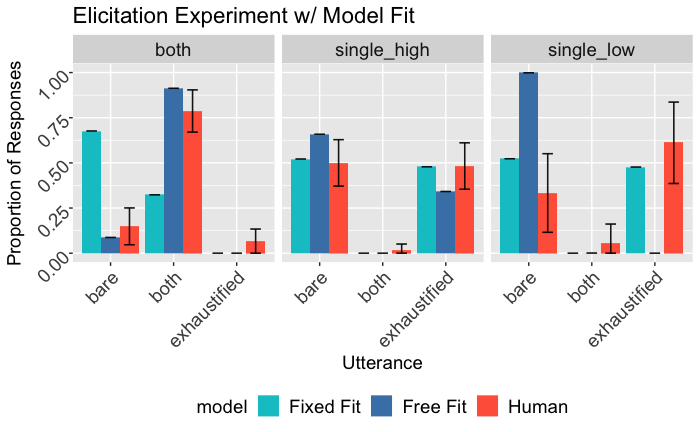

```r
d_rank = d %>%
  arrange(lstnr_spkr_mse)
free_fit = d_rank[1,6:14]
free_fit$model = "Free Fit"
d_rank = d %>%
  filter(c2 <= 2 * c1) %>%
  arrange(lstnr_mse)
fixed_fit = d_rank[1,6:14]
fixed_fit$model = "Fixed Fit"
model_res = rbind(fixed_fit, free_fit) %>%
  gather(utterance,m,c(AB.both, AB.bare, AB.exhaust, A.both, A.bare, A.exhaust, B.both, B.bare, B.exhaust)) %>%
  separate(utterance, c("condition","input"), sep="\\.") %>%
  mutate(input=if_else(input=="exhaust", "exhaustified", input)) %>%
  mutate(condition=if_else(condition=="AB", "both", condition)) %>%
  mutate(condition=if_else(condition=="A", "single_low", condition)) %>%
  mutate(condition=if_else(condition=="B", "single_high", condition)) %>%
  mutate(upper = m,
         lower = m,
         n=m)

d_elicit_model = d_elicit %>%
  group_by(condition) %>%
    mutate(n_in_cond = n()) %>%
  ungroup() %>%
  group_by(condition, input) %>%
    summarise(m = n()/n_in_cond[1],
              se = sqrt(((n()/n_in_cond[1]) * (1-(n()/n_in_cond[1])))/n_in_cond[1]),
              upper = m+1.96*se,
              lower = m-1.96*se,
              n=n()) %>%
  ungroup() %>%
  mutate(model="Human") %>%
  select(-se, -n)
d_free_fit = matrix(data = c("single_low", "bare", 0.998987457, 0.998987457, 0.998987457, "Free Fit",
                              "single_low", "both", 0.001012543, 0.001012543, 0.001012543, "Free Fit",
                              "single_low", "exhaustified", 0.0000000, 0.0000000, 0.0000000, "Free Fit",
                              "single_high", "bare", 0.65835066, 0.65835066, 0.65835066, "Free Fit",
                              "single_high", "both", 0.000000000, 0.000000000, 0.000000000, "Free Fit",
                              "single_high", "exhaustified", 0.3416493, 0.3416493, 0.3416493, "Free Fit",
                              "both", "bare", 0.087256962, 0.087256962, 0.087256962, "Free Fit",
                              "both", "both", 0.912743, 0.912743, 0.912743, "Free Fit",
                              "both", "exhaustified", 0.0000000, 0.0000000, 0.0000000, "Free Fit" ), ncol=6, byrow=TRUE)
colnames(d_free_fit) = c("condition", "input", "m", "upper", "lower", "model")
d_fixed_fit = matrix(data = c("single_low", "bare", 0.5231485, 0.5231485, 0.5231485, "Fixed Fit",
                              "single_low", "both", 0.0, 0.0, 0.0, "Fixed Fit",
                              "single_low", "exhaustified", 0.4768515, 0.4768515, 0.4768515, "Fixed Fit",
                              "single_high", "bare", 0.5214191, 0.5214191, 0.5214191, "Fixed Fit",
                              "single_high", "both", 0.000000000, 0.000000000, 0.000000000, "Fixed Fit",
                              "single_high", "exhaustified", 0.4785809, 0.4785809, 0.4785809, "Fixed Fit",
                              "both", "bare", 0.6766693, 0.6766693, 0.6766693, "Fixed Fit",
                              "both", "both", 0.3233307, 0.3233307, 0.3233307, "Fixed Fit",
                              "both", "exhaustified", 0.0000000, 0.0000000, 0.0000000, "Fixed Fit" ), ncol=6, byrow=TRUE)
colnames(d_fixed_fit) = c("condition", "input", "m", "upper", "lower", "model")
d_elicit_model = d_elicit_model %>%
  rbind(d_elicit_model, d_free_fit, d_fixed_fit) %>%
  mutate(m=as.numeric(m),
         upper=as.numeric(upper),
         lower=as.numeric(lower))
d_elicit_model %>%
  ggplot(aes(x=input, y=m, ymax=upper, ymin=pmax(lower, 0), fill=model)) +
    geom_bar(stat="identity", position="dodge") +
    geom_errorbar(color="black", width=.5, position=position_dodge(width=.9), alpha=0.7) +
    ylab("Proportion of Responses") +
    xlab("Utterance") +
    scale_fill_manual(values=c("turquoise3", "steelblue", "tomato")) +
    ggtitle("Elicitation Experiment w/ Model Fit") +
    facet_grid(~condition) +
    theme(legend.position = 'bottom',
          axis.text=element_text(size=14, angle=45, hjust=1),
          title=element_text(size=14),
          legend.text=element_text(size=14),
          axis.title=element_text(size=14),
          strip.text.x = element_text(size = 14))
```

```r
#ggsave("./images/elicitation_fit.png", width = 7, height = 5)
```